# Risk Factor Analysis

## Outcome Variable

**Outcome Variable:** wast_rec90d

## Predictor Variables

**Intervention Variable:** predfeed3

**Adjustment Set:**

- arm
- sex
- month
- brthmon
- W_mage
- meducyrs
- feducyrs
- hhwealth_quart
- hfoodsec
- W_mhtcm
- W_mwtkg
- W_mbmi
- vagbrth
- W_gagebrth
- W_birthwt
- W_birthlen
- W_nrooms
- W_nchldlt5
- W_parity
- impfloor
- impsan
- safeh20
- delta_W_mage
- delta_meducyrs
- delta_feducyrs
- delta_hhwealth_quart
- delta_hfoodsec
- delta_W_mhtcm
- delta_W_mwtkg
- delta_W_mbmi
- delta_vagbrth
- delta_W_gagebrth
- delta_W_birthwt
- delta_W_birthlen
- delta_W_nrooms
- delta_W_nchldlt5
- delta_W_parity
- delta_impfloor
- delta_impsan
- delta_safeh20

## Stratifying Variables

The analysis was stratified on these variable(s):

- agecat
- studyid
- country

## Data Summary

| agecat | studyid | country | predfeed3 | wast_rec90d | n_cell | n |
| --- | --- | --- | --- | --- | --- | --- |
| 0-24 months | EE | PAKISTAN | 1 | 0 | 14 | 30 |
| 0-24 months | EE | PAKISTAN | 1 | 1 | 16 | 30 |
| 0-24 months | EE | PAKISTAN | 0 | 0 | 0 | 30 |
| 0-24 months | EE | PAKISTAN | 0 | 1 | 0 | 30 |
| 0-24 months | GMS-Nepal | NEPAL | 1 | 0 | 185 | 491 |
| 0-24 months | GMS-Nepal | NEPAL | 1 | 1 | 231 | 491 |
| 0-24 months | GMS-Nepal | NEPAL | 0 | 0 | 32 | 491 |
| 0-24 months | GMS-Nepal | NEPAL | 0 | 1 | 43 | 491 |
| 0-24 months | JiVitA-3 | BANGLADESH | 1 | 0 | 2252 | 4340 |
| 0-24 months | JiVitA-3 | BANGLADESH | 1 | 1 | 1699 | 4340 |
| 0-24 months | JiVitA-3 | BANGLADESH | 0 | 0 | 218 | 4340 |
| 0-24 months | JiVitA-3 | BANGLADESH | 0 | 1 | 171 | 4340 |
| 0-24 months | JiVitA-4 | BANGLADESH | 1 | 0 | 37 | 54 |
| 0-24 months | JiVitA-4 | BANGLADESH | 1 | 1 | 12 | 54 |
| 0-24 months | JiVitA-4 | BANGLADESH | 0 | 0 | 5 | 54 |
| 0-24 months | JiVitA-4 | BANGLADESH | 0 | 1 | 0 | 54 |
| 0-24 months | MAL-ED | BANGLADESH | 1 | 0 | 33 | 117 |
| 0-24 months | MAL-ED | BANGLADESH | 1 | 1 | 68 | 117 |
| 0-24 months | MAL-ED | BANGLADESH | 0 | 0 | 8 | 117 |
| 0-24 months | MAL-ED | BANGLADESH | 0 | 1 | 8 | 117 |
| 0-24 months | MAL-ED | BRAZIL | 1 | 0 | 5 | 22 |
| 0-24 months | MAL-ED | BRAZIL | 1 | 1 | 9 | 22 |
| 0-24 months | MAL-ED | BRAZIL | 0 | 0 | 1 | 22 |
| 0-24 months | MAL-ED | BRAZIL | 0 | 1 | 7 | 22 |
| 0-24 months | MAL-ED | INDIA | 1 | 0 | 43 | 162 |
| 0-24 months | MAL-ED | INDIA | 1 | 1 | 67 | 162 |
| 0-24 months | MAL-ED | INDIA | 0 | 0 | 19 | 162 |
| 0-24 months | MAL-ED | INDIA | 0 | 1 | 33 | 162 |
| 0-24 months | MAL-ED | NEPAL | 1 | 0 | 11 | 96 |
| 0-24 months | MAL-ED | NEPAL | 1 | 1 | 35 | 96 |

[output cut: 102 more lines]

The following strata were considered:

- agecat: 0-24 months, studyid: EE, country: PAKISTAN
- agecat: 0-24 months, studyid: GMS-Nepal, country: NEPAL
- agecat: 0-24 months, studyid: JiVitA-3, country: BANGLADESH
- agecat: 0-24 months, studyid: JiVitA-4, country: BANGLADESH
- agecat: 0-24 months, studyid: MAL-ED, country: BANGLADESH
- agecat: 0-24 months, studyid: MAL-ED, country: BRAZIL
- agecat: 0-24 months, studyid: MAL-ED, country: INDIA
- agecat: 0-24 months, studyid: MAL-ED, country: NEPAL
- agecat: 0-24 months, studyid: MAL-ED, country: PERU
- agecat: 0-24 months, studyid: MAL-ED, country: SOUTH AFRICA
- agecat: 0-24 months, studyid: MAL-ED, country: TANZANIA, UNITED REPUBLIC OF
- agecat: 0-6 months, studyid: EE, country: PAKISTAN
- agecat: 0-6 months, studyid: GMS-Nepal, country: NEPAL
- agecat: 0-6 months, studyid: JiVitA-3, country: BANGLADESH
- agecat: 0-6 months, studyid: JiVitA-4, country: BANGLADESH
- agecat: 0-6 months, studyid: MAL-ED, country: BANGLADESH
- agecat: 0-6 months, studyid: MAL-ED, country: BRAZIL
- agecat: 0-6 months, studyid: MAL-ED, country: INDIA
- agecat: 0-6 months, studyid: MAL-ED, country: NEPAL
- agecat: 0-6 months, studyid: MAL-ED, country: PERU
- agecat: 0-6 months, studyid: MAL-ED, country: SOUTH AFRICA
- agecat: 0-6 months, studyid: MAL-ED, country: TANZANIA, UNITED REPUBLIC OF
- agecat: 6-24 months, studyid: EE, country: PAKISTAN
- agecat: 6-24 months, studyid: GMS-Nepal, country: NEPAL
- agecat: 6-24 months, studyid: JiVitA-3, country: BANGLADESH
- agecat: 6-24 months, studyid: JiVitA-4, country: BANGLADESH
- agecat: 6-24 months, studyid: MAL-ED, country: BANGLADESH
- agecat: 6-24 months, studyid: MAL-ED, country: BRAZIL
- agecat: 6-24 months, studyid: MAL-ED, country: INDIA
- agecat: 6-24 months, studyid: MAL-ED, country: NEPAL
- agecat: 6-24 months, studyid: MAL-ED, country: PERU
- agecat: 6-24 months, studyid: MAL-ED, country: SOUTH AFRICA
- agecat: 6-24 months, studyid: MAL-ED, country: TANZANIA, UNITED REPUBLIC OF

### Dropped Strata

Some strata were dropped due to rare outcomes:

- agecat: 0-24 months, studyid: EE, country: PAKISTAN
- agecat: 0-24 months, studyid: JiVitA-4, country: BANGLADESH
- agecat: 0-24 months, studyid: MAL-ED, country: BRAZIL
- agecat: 0-24 months, studyid: MAL-ED, country: PERU
- agecat: 0-24 months, studyid: MAL-ED, country: SOUTH AFRICA
- agecat: 0-24 months, studyid: MAL-ED, country: TANZANIA, UNITED REPUBLIC OF
- agecat: 0-6 months, studyid: EE, country: PAKISTAN
- agecat: 0-6 months, studyid: JiVitA-4, country: BANGLADESH
- agecat: 0-6 months, studyid: MAL-ED, country: BANGLADESH
- agecat: 0-6 months, studyid: MAL-ED, country: BRAZIL
- agecat: 0-6 months, studyid: MAL-ED, country: NEPAL
- agecat: 0-6 months, studyid: MAL-ED, country: PERU
- agecat: 0-6 months, studyid: MAL-ED, country: SOUTH AFRICA
- agecat: 0-6 months, studyid: MAL-ED, country: TANZANIA, UNITED REPUBLIC OF
- agecat: 6-24 months, studyid: EE, country: PAKISTAN
- agecat: 6-24 months, studyid: JiVitA-3, country: BANGLADESH
- agecat: 6-24 months, studyid: JiVitA-4, country: BANGLADESH
- agecat: 6-24 months, studyid: MAL-ED, country: BANGLADESH
- agecat: 6-24 months, studyid: MAL-ED, country: BRAZIL
- agecat: 6-24 months, studyid: MAL-ED, country: NEPAL
- agecat: 6-24 months, studyid: MAL-ED, country: PERU
- agecat: 6-24 months, studyid: MAL-ED, country: SOUTH AFRICA
- agecat: 6-24 months, studyid: MAL-ED, country: TANZANIA, UNITED REPUBLIC OF

## Methods Detail

We’re interested in the causal parameters $E[Y_a]$ for all values of $a \in \mathcal{A}$. These parameters represent the mean outcome if, possibly contrary to fact, we intervened to set all units to have $A=a$. Under the randomization and positivity assumptions, these are identified by the statistical parameters $\psi_a=E_W[E_{Y|A,W}(Y|A=a,W)]$. In addition, we’re interested in the mean of $Y$, $E[Y]$ under no intervention (the observed mean). We will estimate these parameters by using SuperLearner to fit the relevant likelihood factors – $E_{Y|A,W}(Y|A=a,W)$ and $p(A=a|W)$, and then updating our likelihood fit using a joint TMLE.

For unadjusted analyses ($W=\{\}$), initial likelihoods were estimated using Lrnr_glm to estimate the simple $E(Y|A)$ and Lrnr_mean to estimate $p(A)$. For adjusted analyses, a small library containing Lrnr_glmnet, Lrnr_xgboost, and Lrnr_mean was used.

Having estimated these parameters, we will then use the delta method to estimate relative risks and attributable risks relative to a prespecified baseline level of $A$.

# Results Detail

## Results Plots

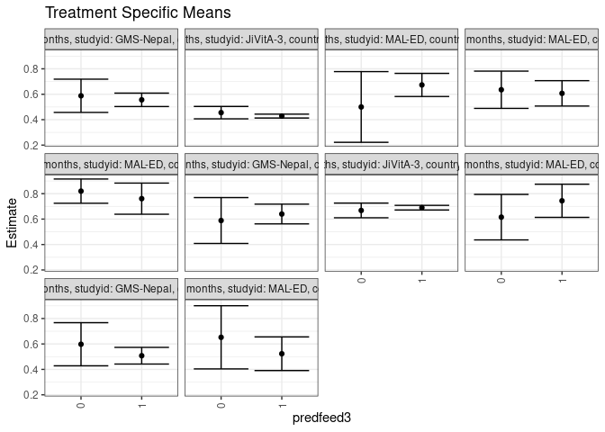

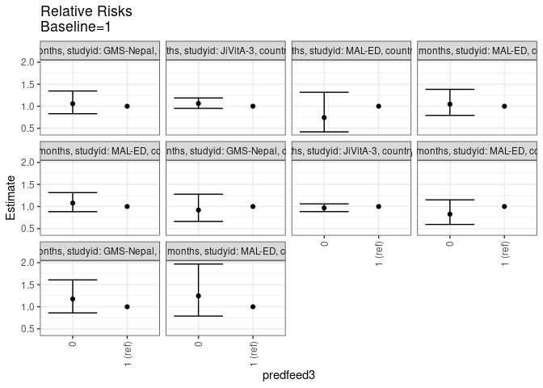

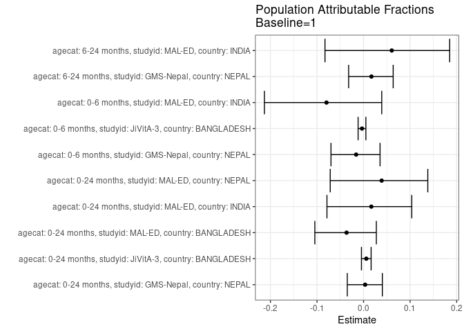

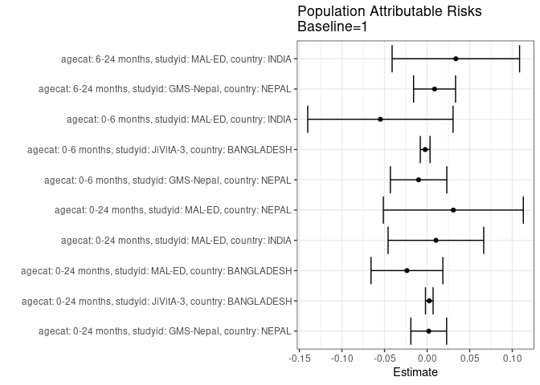

## Results Table

### Parameter: TSM

| agecat | studyid | country | intervention_level | baseline_level | estimate | ci_lower | ci_upper |
| --- | --- | --- | --- | --- | --- | --- | --- |
| 0-24 months | GMS-Nepal | NEPAL | 1 | NA | 0.5561398 | 0.5033957 | 0.6088839 |
| 0-24 months | GMS-Nepal | NEPAL | 0 | NA | 0.5878812 | 0.4572546 | 0.7185079 |
| 0-24 months | JiVitA-3 | BANGLADESH | 1 | NA | 0.4283263 | 0.4130617 | 0.4435910 |
| 0-24 months | JiVitA-3 | BANGLADESH | 0 | NA | 0.4554143 | 0.4066463 | 0.5041824 |
| 0-24 months | MAL-ED | BANGLADESH | 1 | NA | 0.6732673 | 0.5822997 | 0.7642350 |
| 0-24 months | MAL-ED | BANGLADESH | 0 | NA | 0.5000000 | 0.2219425 | 0.7780575 |
| 0-24 months | MAL-ED | INDIA | 1 | NA | 0.6069763 | 0.5070921 | 0.7068605 |
| 0-24 months | MAL-ED | INDIA | 0 | NA | 0.6354645 | 0.4888879 | 0.7820412 |
| 0-24 months | MAL-ED | NEPAL | 1 | NA | 0.7608696 | 0.6384483 | 0.8832909 |
| 0-24 months | MAL-ED | NEPAL | 0 | NA | 0.8200000 | 0.7247720 | 0.9152280 |
| 0-6 months | GMS-Nepal | NEPAL | 1 | NA | 0.6398466 | 0.5622293 | 0.7174639 |
| 0-6 months | GMS-Nepal | NEPAL | 0 | NA | 0.5887727 | 0.4083348 | 0.7692106 |
| 0-6 months | JiVitA-3 | BANGLADESH | 1 | NA | 0.6897826 | 0.6715395 | 0.7080258 |
| 0-6 months | JiVitA-3 | BANGLADESH | 0 | NA | 0.6680977 | 0.6104005 | 0.7257949 |
| 0-6 months | MAL-ED | INDIA | 1 | NA | 0.7440478 | 0.6135165 | 0.8745790 |
| 0-6 months | MAL-ED | INDIA | 0 | NA | 0.6153684 | 0.4364115 | 0.7943253 |
| 6-24 months | GMS-Nepal | NEPAL | 1 | NA | 0.5073714 | 0.4417907 | 0.5729521 |
| 6-24 months | GMS-Nepal | NEPAL | 0 | NA | 0.5976086 | 0.4279354 | 0.7672818 |
| 6-24 months | MAL-ED | INDIA | 1 | NA | 0.5230769 | 0.3907677 | 0.6553862 |
| 6-24 months | MAL-ED | INDIA | 0 | NA | 0.6521739 | 0.4038225 | 0.9005253 |

### Parameter: E(Y)

| agecat | studyid | country | intervention_level | baseline_level | estimate | ci_lower | ci_upper |
| --- | --- | --- | --- | --- | --- | --- | --- |
| 0-24 months | GMS-Nepal | NEPAL | NA | NA | 0.5580448 | 0.5093588 | 0.6067308 |
| 0-24 months | JiVitA-3 | BANGLADESH | NA | NA | 0.4308756 | 0.4161410 | 0.4456101 |
| 0-24 months | MAL-ED | BANGLADESH | NA | NA | 0.6495726 | 0.5607849 | 0.7383604 |
| 0-24 months | MAL-ED | INDIA | NA | NA | 0.6172840 | 0.5340594 | 0.7005085 |
| 0-24 months | MAL-ED | NEPAL | NA | NA | 0.7916667 | 0.7146386 | 0.8686947 |
| 0-6 months | GMS-Nepal | NEPAL | NA | NA | 0.6298343 | 0.5587812 | 0.7008873 |
| 0-6 months | JiVitA-3 | BANGLADESH | NA | NA | 0.6875000 | 0.6700777 | 0.7049223 |
| 0-6 months | MAL-ED | INDIA | NA | NA | 0.6891892 | 0.5810852 | 0.7972932 |
| 6-24 months | GMS-Nepal | NEPAL | NA | NA | 0.5161290 | 0.4555456 | 0.5767125 |
| 6-24 months | MAL-ED | INDIA | NA | NA | 0.5568182 | 0.4384773 | 0.6751591 |

### Parameter: RR

| agecat | studyid | country | intervention_level | baseline_level | estimate | ci_lower | ci_upper |
| --- | --- | --- | --- | --- | --- | --- | --- |
| 0-24 months | GMS-Nepal | NEPAL | 1 | 1 | 1.0000000 | 1.0000000 | 1.000000 |
| 0-24 months | GMS-Nepal | NEPAL | 0 | 1 | 1.0570745 | 0.8302242 | 1.345909 |
| 0-24 months | JiVitA-3 | BANGLADESH | 1 | 1 | 1.0000000 | 1.0000000 | 1.000000 |
| 0-24 months | JiVitA-3 | BANGLADESH | 0 | 1 | 1.0632415 | 0.9511784 | 1.188507 |
| 0-24 months | MAL-ED | BANGLADESH | 1 | 1 | 1.0000000 | 1.0000000 | 1.000000 |
| 0-24 months | MAL-ED | BANGLADESH | 0 | 1 | 0.7426471 | 0.4190238 | 1.316213 |
| 0-24 months | MAL-ED | INDIA | 1 | 1 | 1.0000000 | 1.0000000 | 1.000000 |
| 0-24 months | MAL-ED | INDIA | 0 | 1 | 1.0469346 | 0.7924703 | 1.383108 |
| 0-24 months | MAL-ED | NEPAL | 1 | 1 | 1.0000000 | 1.0000000 | 1.000000 |
| 0-24 months | MAL-ED | NEPAL | 0 | 1 | 1.0777143 | 0.8831354 | 1.315164 |
| 0-6 months | GMS-Nepal | NEPAL | 1 | 1 | 1.0000000 | 1.0000000 | 1.000000 |
| 0-6 months | GMS-Nepal | NEPAL | 0 | 1 | 0.9201779 | 0.6618229 | 1.279387 |
| 0-6 months | JiVitA-3 | BANGLADESH | 1 | 1 | 1.0000000 | 1.0000000 | 1.000000 |
| 0-6 months | JiVitA-3 | BANGLADESH | 0 | 1 | 0.9685626 | 0.8850714 | 1.059930 |
| 0-6 months | MAL-ED | INDIA | 1 | 1 | 1.0000000 | 1.0000000 | 1.000000 |
| 0-6 months | MAL-ED | INDIA | 0 | 1 | 0.8270550 | 0.5942669 | 1.151031 |
| 6-24 months | GMS-Nepal | NEPAL | 1 | 1 | 1.0000000 | 1.0000000 | 1.000000 |
| 6-24 months | GMS-Nepal | NEPAL | 0 | 1 | 1.1778524 | 0.8613875 | 1.610583 |
| 6-24 months | MAL-ED | INDIA | 1 | 1 | 1.0000000 | 1.0000000 | 1.000000 |
| 6-24 months | MAL-ED | INDIA | 0 | 1 | 1.2468031 | 0.7893061 | 1.969474 |

### Parameter: PAR

| agecat | studyid | country | intervention_level | baseline_level | estimate | ci_lower | ci_upper |
| --- | --- | --- | --- | --- | --- | --- | --- |
| 0-24 months | GMS-Nepal | NEPAL | 1 | NA | 0.0019050 | -0.0191054 | 0.0229154 |
| 0-24 months | JiVitA-3 | BANGLADESH | 1 | NA | 0.0025492 | -0.0019255 | 0.0070239 |
| 0-24 months | MAL-ED | BANGLADESH | 1 | NA | -0.0236947 | -0.0658584 | 0.0184690 |
| 0-24 months | MAL-ED | INDIA | 1 | NA | 0.0103077 | -0.0458385 | 0.0664538 |
| 0-24 months | MAL-ED | NEPAL | 1 | NA | 0.0307971 | -0.0513830 | 0.1129772 |
| 0-6 months | GMS-Nepal | NEPAL | 1 | NA | -0.0100123 | -0.0431396 | 0.0231149 |
| 0-6 months | JiVitA-3 | BANGLADESH | 1 | NA | -0.0022826 | -0.0080080 | 0.0034427 |
| 0-6 months | MAL-ED | INDIA | 1 | NA | -0.0548586 | -0.1401716 | 0.0304544 |
| 6-24 months | GMS-Nepal | NEPAL | 1 | NA | 0.0087576 | -0.0158866 | 0.0334019 |
| 6-24 months | MAL-ED | INDIA | 1 | NA | 0.0337413 | -0.0410835 | 0.1085660 |

### Parameter: PAF

| agecat | studyid | country | intervention_level | baseline_level | estimate | ci_lower | ci_upper |
| --- | --- | --- | --- | --- | --- | --- | --- |
| 0-24 months | GMS-Nepal | NEPAL | 1 | NA | 0.0034137 | -0.0349534 | 0.0403584 |
| 0-24 months | JiVitA-3 | BANGLADESH | 1 | NA | 0.0059164 | -0.0045188 | 0.0162432 |
| 0-24 months | MAL-ED | BANGLADESH | 1 | NA | -0.0364773 | -0.1046400 | 0.0274793 |
| 0-24 months | MAL-ED | INDIA | 1 | NA | 0.0166984 | -0.0786016 | 0.1035781 |
| 0-24 months | MAL-ED | NEPAL | 1 | NA | 0.0389016 | -0.0715585 | 0.1379751 |
| 0-6 months | GMS-Nepal | NEPAL | 1 | NA | -0.0158968 | -0.0699599 | 0.0354346 |
| 0-6 months | JiVitA-3 | BANGLADESH | 1 | NA | -0.0033202 | -0.0116846 | 0.0049750 |
| 0-6 months | MAL-ED | INDIA | 1 | NA | -0.0795987 | -0.2129160 | 0.0390650 |
| 6-24 months | GMS-Nepal | NEPAL | 1 | NA | 0.0169679 | -0.0320188 | 0.0636294 |
| 6-24 months | MAL-ED | INDIA | 1 | NA | 0.0605965 | -0.0828181 | 0.1850165 |